# 資料視覺化

[數據交點](https://www.datainpoint.com) | 郭耀仁 yaojenkuo@datainpoint.com

> The simple graph has brought more information to the data analyst’s mind than any other device.

> [John Tukey](https://en.wikipedia.org/wiki/John_Tukey)

## 暸解資料視覺化

1. 資料視覺化的 What 與 Why。
2. 資料視覺化的工具箱。
3. 用四個面向考量資料視覺化的工具。

## 資料視覺化的 What 與 Why

## 何謂資料視覺化

> 資料視覺化是一門致力於將抽象性概念具體化的學科，透過圖形、顏色、形狀或大小等元素把原始資料或函式等所蘊含的特徵傳達給瀏覽者，進而將抽象的資訊轉換為溝通對象能快速掌握理解的精簡內容。

## 資料視覺化是現代資料科學應用的一個環節

[figure not shown]

來源：[R for Data Science](https://r4ds.had.co.nz/)

## 為何資料視覺化

- 原始數列資料、函數對瀏覽者而言是抽象、不具資訊價值的。
- 資料視覺化對瀏覽者而言是具體、具有資訊價值的。

## 抽象的原始數列資料

```python
print(arr)
```

```
[-1.07758271  1.55224998 -0.7295749  ... -0.18354096  0.51732877
  2.35621533]
```

## 函數是抽象的

\begin{equation} f(p) = -y_{true}log(p)-(1-y_{true})log(1-p) \\ y_{true} \in \{ 0, 1 \} \end{equation}

## 函數是抽象的（續）

\begin{equation} f(x) = \frac{1}{1 + e^{-x}} \end{equation}

## 資料視覺化對瀏覽者而言是具體、具有資訊價值的

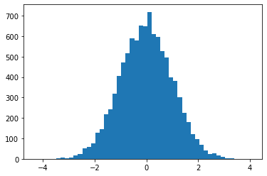

```python
plot_normal(arr)
```

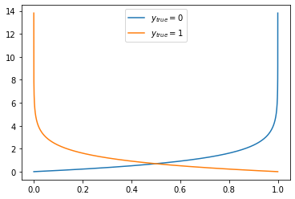

```python
plot_cross_entropy(p, log_loss_0, log_loss_1)
```

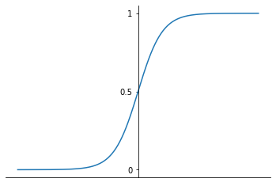

```python
plot_sigmoid(x, y)
```

## 經典視覺化：有資訊價值、簡潔以及美觀

- [Charles Minard's map of Napoleon's disastrous Russian campaign of 1812](https://en.wikipedia.org/wiki/Charles_Joseph_Minard#/media/File:Minard.png)
- [Hans Rosling's 200 Countries, 200 Years, 4 Minutes](https://youtu.be/jbkSRLYSojo)

## 資料視覺化的工具箱

## 如何做資料視覺化？

[figure not shown]

來源：https://giphy.com

## 有一半的難關不是在作圖

> When it comes to making graphs, half the battle occurs before you call any graphing commands.

> [Winston Chang](https://twitter.com/winston_chang?lang=en)

## 有一半的難關在於資料視覺化的前置作業

[figure not shown]

來源：[R for Data Science](https://r4ds.had.co.nz/)

## 資料視覺化三步驟

1. 獲取資料。
2. 將資料整理為合適的格式與類型。
3. 輸入資料視覺化套件所定義好的函數。

## 各據山頭的資料視覺化工具

- 商業智慧軟體
- 程式語言
  - Python
  - R

## 商業智慧軟體

- PowerBI
- Tableau

## Python 的資料視覺化模組

- [Matplotlib](https://matplotlib.org/)
- [Seaborn](https://seaborn.pydata.org/)
- [Plotly](https://plotly.com/)
- [Folium](https://python-visualization.github.io/folium/)
- [Dash](https://plotly.com/dash/)
- [Streamlit](https://www.streamlit.io/)

## R 的資料視覺化模組

- Base Plotting System
- Ggplot2
- Plotly
- Shiny

## 用四個面向考量資料視覺化的工具

## 資料視覺化工具這麼多，該怎麼選擇？

## 我建議可以考量四個面向

1. 使用者數量（「西瓜偎大邊」與「衝量」哲學）。
2. 互動性。
3. 語法與彈性。
4. 資料格式與視覺化類型。

## 考量使用者數量

[figure not shown]

來源：[Stack Overflow Trends](https://insights.stackoverflow.com/trends?tags=matplotlib%2Cseaborn%2Cplotly%2Cbokeh%2Cggplot2%2Cleaflet)

```
Which of the following business intelligence tools do you use on a regular basis? (Select all that apply)
Too many categories, only showing the top 10.
```

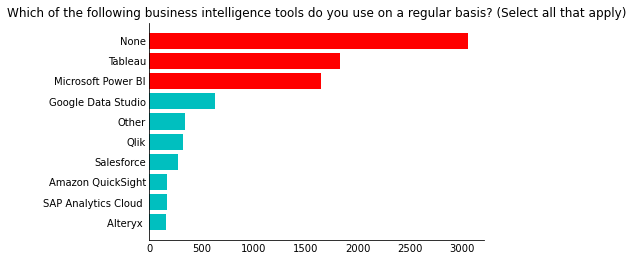

```python
ks.plot_summary('Q31A')
```

```
What data visualization libraries or tools do you use on a regular basis?  (Select all that apply)
Too many categories, only showing the top 10.
```

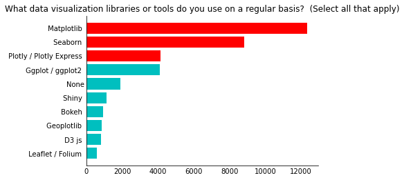

```python
ks.plot_summary("Q14")
```

## 考量互動性

靜態 vs. 動態。

## 考量語法與彈性

- 物件導向型 vs. 陳述型。
- 低階 vs. 高階。

## 考量資料格式與視覺化類型

- 資料格式：陣列、資料框或 JSON 等。
- 特定的視覺化：樹狀圖、地理資訊或 Sankey Diagram 等。

## 簡而言之，商業智慧軟體

- Windows 作業系統
  - [Tableau](https://public.tableau.com/en-us/s/download)
  - [PowerBI](https://powerbi.microsoft.com/zh-tw/downloads/)
- macOS
  - [Tableau](https://public.tableau.com/en-us/s/download)

## 簡而言之，Python 的視覺化模組

- 靜態
  - 低階：[Matplotlib](https://matplotlib.org/)
  - 高階：[Seaborn](https://seaborn.pydata.org/)
- 動態
  - 在筆記本中：[Plotly](https://plotly.com/)
  - 獨立網頁應用：[Dash](https://plotly.com/dash/) / [Streamlit](https://www.streamlit.io/)

## 簡而言之，R 的視覺化模組

- 靜態
  - 低階：[Base Plotting System](http://www.cookbook-r.com/Graphs/)
  - 高階：[Ggplot2](https://ggplot2.tidyverse.org/)
- 動態
  - 在筆記本中：[Plotly](https://plotly.com/)
  - 獨立網頁應用：[Shiny](https://shiny.rstudio.com/)

## 試用看看、參考範例

- [Matplotlib](https://matplotlib.org/stable/gallery/index.html)
- [Seaborn](https://seaborn.pydata.org/examples/index.html)
- [Plotly](https://plotly.com/python/)
- [Dash](https://dash.gallery/Portal/)
- [Streamlit](https://streamlit.io/gallery)

## 試用看看、參考範例（續）

- [Base Plotting System](https://www.r-graph-gallery.com/)
- [Ggplot2](https://www.r-graph-gallery.com/ggplot2-package.html)
- [Plotly](https://plotly.com/r/)
- [Shiny](https://shiny.rstudio.com/gallery/)